# JELSCH BOND 2_0_0.15_10_Difference

## Sample=1ejg-a:15:c-a:16:n-a:15:o

| pdb_code | central atom | ca density | parallel atom | pa density | planar atom | pl density |
| --- | --- | --- | --- | --- | --- | --- |
| 1ejg | [3.31, 3.77, 0.97] | 1.4663 | [3.27, 4.91, 1.7] | 14.8155 | [2.97, 3.73, -0.21] | -2.9082 |

## Slices along x,y and z

Sliced x-wise

Sliced y-wise

Sliced z-wise

33/67

33/67

33/67

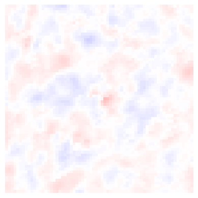

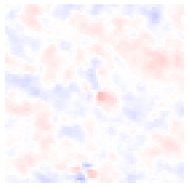

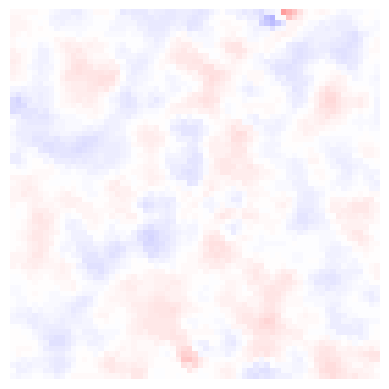

## Sample=1ejg-a:17:c-a:18:n-a:17:o

| pdb_code | central atom | ca density | parallel atom | pa density | planar atom | pl density |
| --- | --- | --- | --- | --- | --- | --- |
| 1ejg | [5.64, 5.55, -2.45] | 13.0754 | [5.05, 4.36, -2.27] | 8.9088 | [6.03, 5.93, -3.56] | -6.4892 |

## Slices along x,y and z

Sliced x-wise

Sliced y-wise

Sliced z-wise

33/67

33/67

33/67

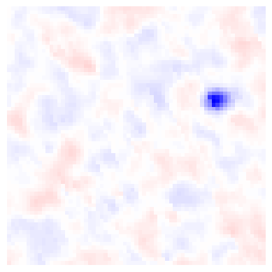

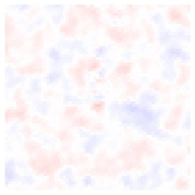

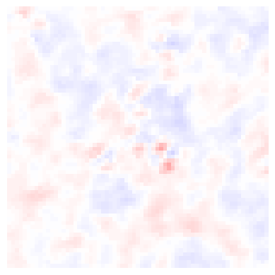

## Sample=1ejg-a:16:c-a:17:n-a:16:o

| pdb_code | central atom | ca density | parallel atom | pa density | planar atom | pl density |
| --- | --- | --- | --- | --- | --- | --- |
| 1ejg | [3.68, 6.5, -0.17] | 11.86 | [4.98, 6.17, -0.14] | 7.0034 | [3.16, 7.04, -1.15] | -16.7731 |

## Slices along x,y and z

Sliced x-wise

Sliced y-wise

Sliced z-wise

33/67

33/67

33/67

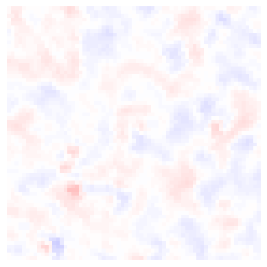

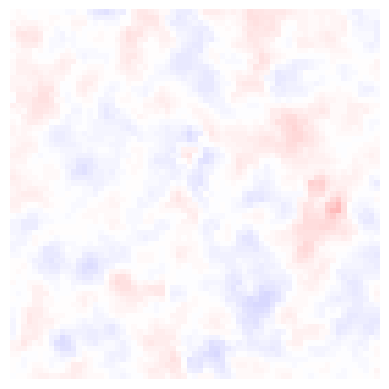

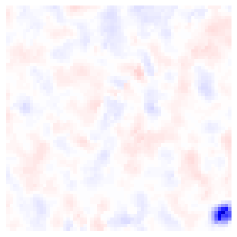

## Sample=1ejg-a:26:c-a:27:n-a:26:o

| pdb_code | central atom | ca density | parallel atom | pa density | planar atom | pl density |
| --- | --- | --- | --- | --- | --- | --- |
| 1ejg | [4.61, 11.82, 4.56] | -1.0261 | [5.4, 12.89, 4.7] | -10.6623 | [4.23, 11.14, 5.53] | 0.394 |

## Slices along x,y and z

Sliced x-wise

Sliced y-wise

Sliced z-wise

33/67

33/67

33/67

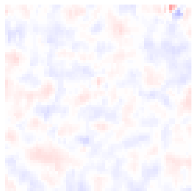

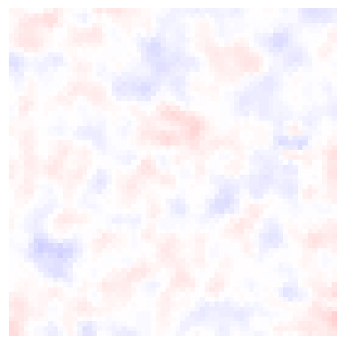

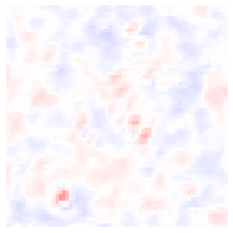

## Sample=1ejg-a:27:c-a:28:n-a:27:o

| pdb_code | central atom | ca density | parallel atom | pa density | planar atom | pl density |
| --- | --- | --- | --- | --- | --- | --- |
| 1ejg | [4.66, 13.85, 6.85] | 0.8408 | [3.86, 14.77, 6.32] | -4.4983 | [4.48, 13.37, 7.97] | 3.2026 |

## Slices along x,y and z

Sliced x-wise

Sliced y-wise

Sliced z-wise

33/67

33/67

33/67

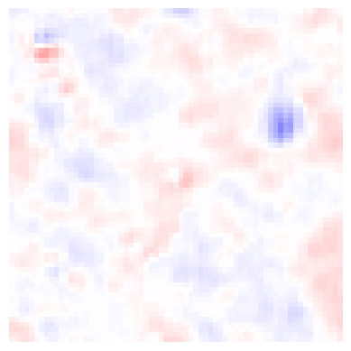

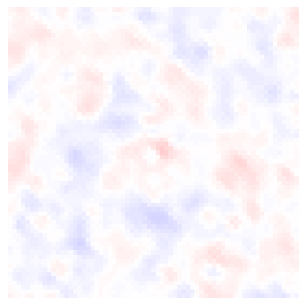

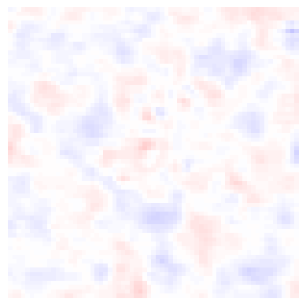

## Sample=1ejg-a:10:c-a:11:n-a:10:o

| pdb_code | central atom | ca density | parallel atom | pa density | planar atom | pl density |
| --- | --- | --- | --- | --- | --- | --- |
| 1ejg | [7.81, 3.58, 7.81] | -3.6486 | [7.21, 2.52, 8.37] | -6.603 | [7.84, 3.74, 6.58] | 5.3911 |

## Slices along x,y and z

Sliced x-wise

Sliced y-wise

Sliced z-wise

33/67

33/67

33/67

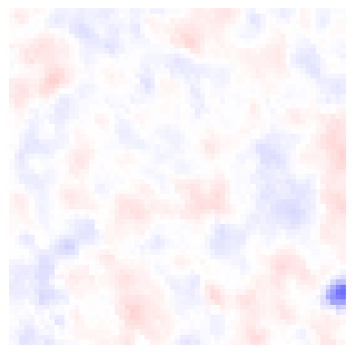

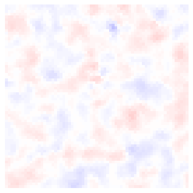

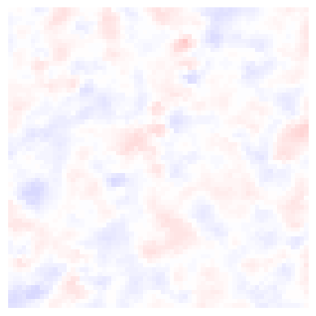

## Sample=1ejg-a:25:c-a:26:n-a:25:o

| pdb_code | central atom | ca density | parallel atom | pa density | planar atom | pl density |
| --- | --- | --- | --- | --- | --- | --- |
| 1ejg | [3.11, 13.57, 2.64] | 12.3977 | [4.03, 12.63, 2.29] | 17.7445 | [2.33, 13.4, 3.58] | 13.1708 |

## Slices along x,y and z

Sliced x-wise

Sliced y-wise

Sliced z-wise

33/67

33/67

33/67

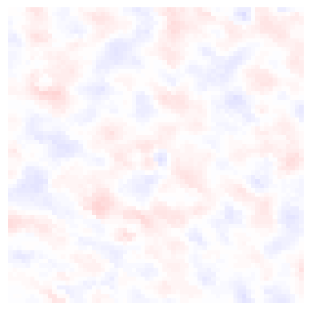

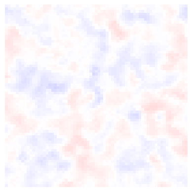

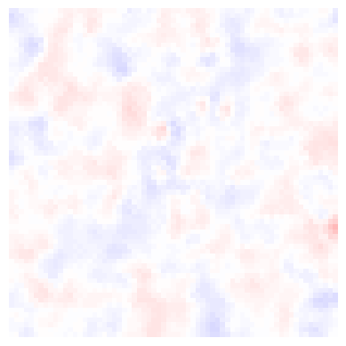

## Sample=1ejg-a:14:c-a:15:n-a:14:o

| pdb_code | central atom | ca density | parallel atom | pa density | planar atom | pl density |
| --- | --- | --- | --- | --- | --- | --- |
| 1ejg | [6.14, 3.15, 1.89] | 10.3015 | [4.99, 2.82, 2.5] | -11.0446 | [6.25, 3.12, 0.66] | -15.6786 |

## Slices along x,y and z

Sliced x-wise

Sliced y-wise

Sliced z-wise

33/67

33/67

33/67

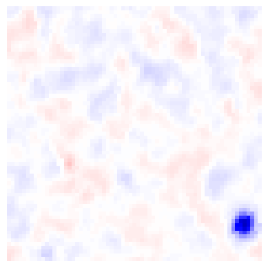

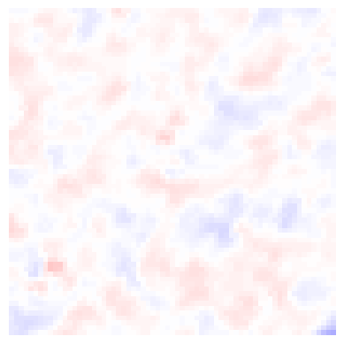

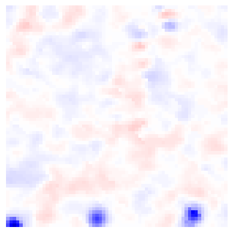

## Sample=1ejg-a:19:c-a:20:n-a:19:o

| pdb_code | central atom | ca density | parallel atom | pa density | planar atom | pl density |
| --- | --- | --- | --- | --- | --- | --- |
| 1ejg | [3.43, 6.55, -6.32] | -5.6281 | [4.42, 7.03, -5.56] | 19.5364 | [3.09, 7.06, -7.38] | -14.6584 |

## Slices along x,y and z

Sliced x-wise

Sliced y-wise

Sliced z-wise

33/67

33/67

33/67

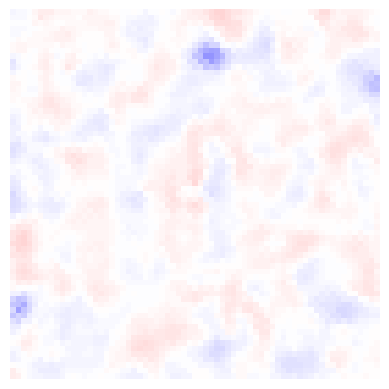

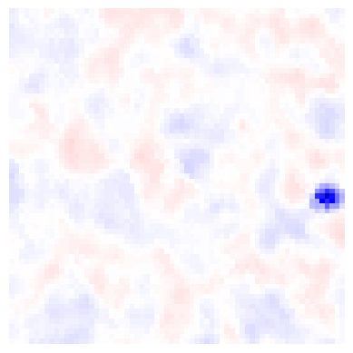

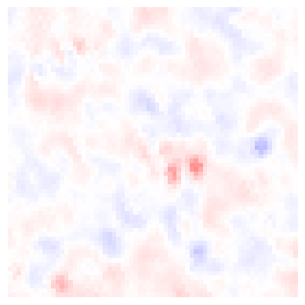

## Sample=1ejg-a:24:c-a:25:n-a:24:o

| pdb_code | central atom | ca density | parallel atom | pa density | planar atom | pl density |
| --- | --- | --- | --- | --- | --- | --- |
| 1ejg | [5.19, 15.82, 2.39] | -0.2463 | [4.4, 15.29, 1.44] | -6.8185 | [4.8, 16.04, 3.53] | 6.2445 |

## Slices along x,y and z

Sliced x-wise

Sliced y-wise

Sliced z-wise

33/67

33/67

33/67

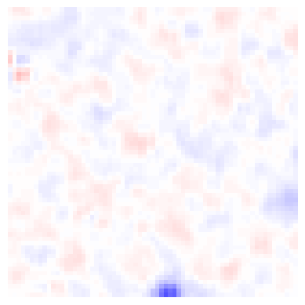

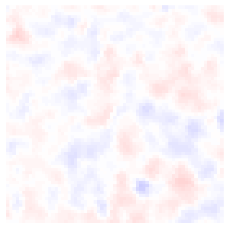

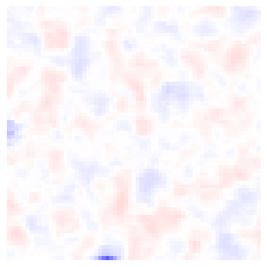

## Sample=1ejg-a:5:c-a:6:n-a:5:o

| pdb_code | central atom | ca density | parallel atom | pa density | planar atom | pl density |
| --- | --- | --- | --- | --- | --- | --- |
| 1ejg | [9.37, 7.69, 15.55] | 4.4301 | [8.93, 6.7, 14.76] | 11.682 | [9.64, 7.54, 16.75] | -0.5327 |

## Slices along x,y and z

Sliced x-wise

Sliced y-wise

Sliced z-wise

33/67

33/67

33/67

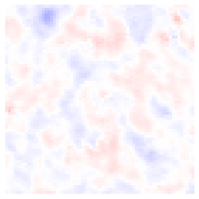

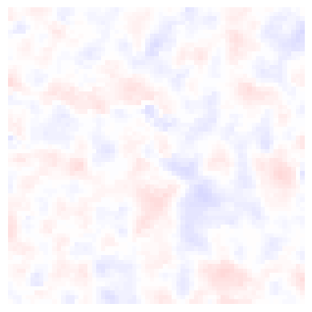

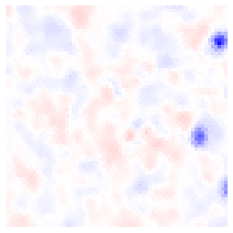

## Sample=1ejg-a:41:c-a:42:n-a:41:o

| pdb_code | central atom | ca density | parallel atom | pa density | planar atom | pl density |
| --- | --- | --- | --- | --- | --- | --- |
| 1ejg | [17.35, 11.97, 16.53] | -17.7747 | [17.64, 11.91, 17.85] | -10.7702 | [16.63, 11.15, 15.97] | -10.5667 |

## Slices along x,y and z

Sliced x-wise

Sliced y-wise

Sliced z-wise

33/67

33/67

33/67

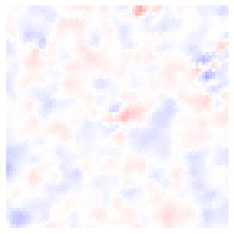

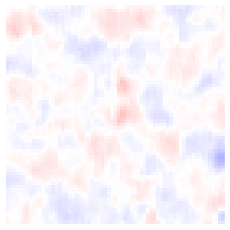

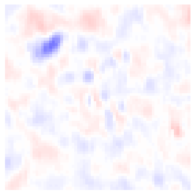

## Sample=1ejg-a:18:c-a:19:n-a:18:o

| pdb_code | central atom | ca density | parallel atom | pa density | planar atom | pl density |
| --- | --- | --- | --- | --- | --- | --- |
| 1ejg | [4.32, 4.01, -4.64] | 25.892 | [3.21, 4.75, -4.57] | -2.6398 | [4.85, 3.78, -5.74] | -0.546 |

## Slices along x,y and z

Sliced x-wise

Sliced y-wise

Sliced z-wise

33/67

33/67

33/67

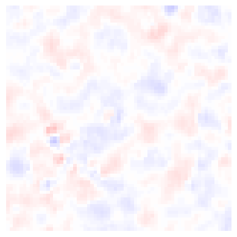

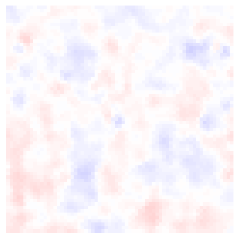

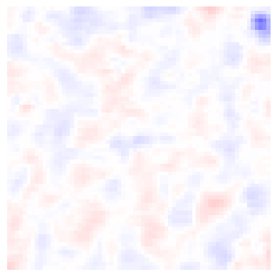

## Sample=1ejg-a:21:c-a:22:n-a:21:o

| pdb_code | central atom | ca density | parallel atom | pa density | planar atom | pl density |
| --- | --- | --- | --- | --- | --- | --- |
| 1ejg | [4.91, 11.35, -3.0] | 26.4053 | [4.91, 12.68, -3.1] | 17.1398 | [5.84, 10.73, -2.48] | 5.9699 |

## Slices along x,y and z

Sliced x-wise

Sliced y-wise

Sliced z-wise

33/67

33/67

33/67

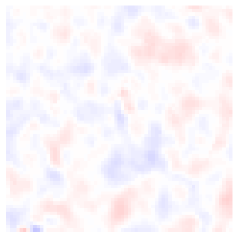

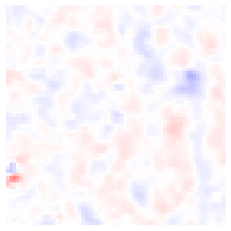

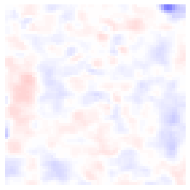

## Sample=1ejg-a:12:c-a:13:n-a:12:o

| pdb_code | central atom | ca density | parallel atom | pa density | planar atom | pl density |
| --- | --- | --- | --- | --- | --- | --- |
| 1ejg | [4.15, 4.79, 5.65] | -9.721 | [5.29, 5.43, 5.95] | 14.4502 | [3.55, 4.96, 4.58] | -10.5439 |

## Slices along x,y and z

Sliced x-wise

Sliced y-wise

Sliced z-wise

33/67

33/67

33/67

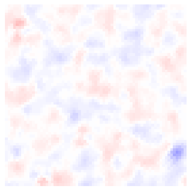

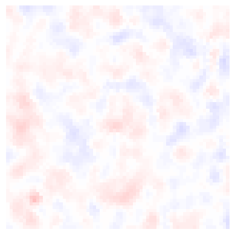

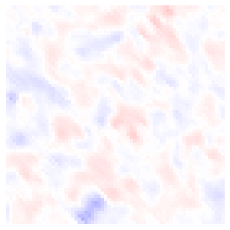

## Sample=1ejg-a:11:c-a:12:n-a:11:o

| pdb_code | central atom | ca density | parallel atom | pa density | planar atom | pl density |
| --- | --- | --- | --- | --- | --- | --- |
| 1ejg | [5.41, 2.24, 6.71] | -8.9319 | [4.66, 3.12, 7.38] | -12.3286 | [5.23, 2.0, 5.52] | 0.5089 |

## Slices along x,y and z

Sliced x-wise

Sliced y-wise

Sliced z-wise

33/67

33/67

33/67

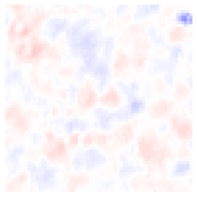

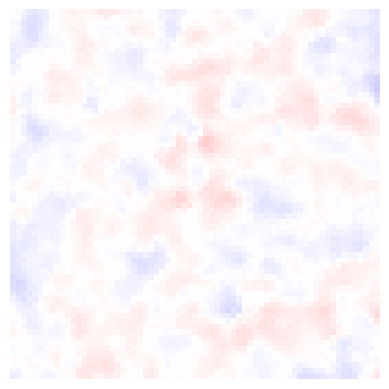

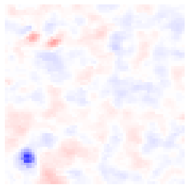

## Sample=1ejg-a:4:c-a:5:n-a:4:o

| pdb_code | central atom | ca density | parallel atom | pa density | planar atom | pl density |
| --- | --- | --- | --- | --- | --- | --- |
| 1ejg | [10.68, 8.74, 12.84] | 16.0009 | [9.55, 9.09, 13.48] | 9.2782 | [11.65, 8.27, 13.42] | -10.1216 |

## Slices along x,y and z

Sliced x-wise

Sliced y-wise

Sliced z-wise

33/67

33/67

33/67

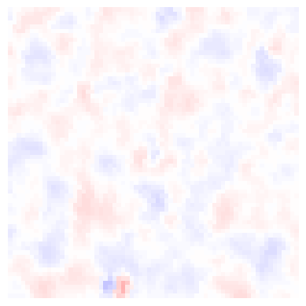

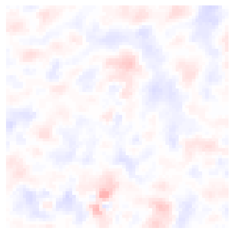

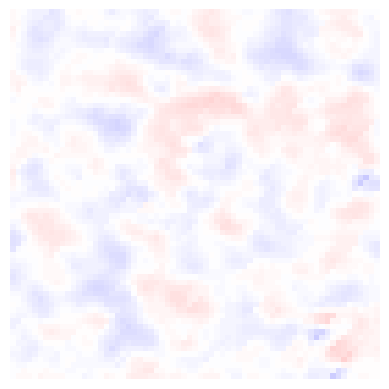

## Sample=1ejg-a:13:c-a:14:n-a:13:o

| pdb_code | central atom | ca density | parallel atom | pa density | planar atom | pl density |
| --- | --- | --- | --- | --- | --- | --- |
| 1ejg | [6.31, 5.55, 3.72] | -6.1457 | [6.89, 4.36, 3.91] | 4.9549 | [6.09, 6.02, 2.61] | -9.1919 |

## Slices along x,y and z

Sliced x-wise

Sliced y-wise

Sliced z-wise

33/67

33/67

33/67

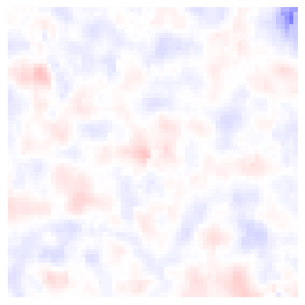

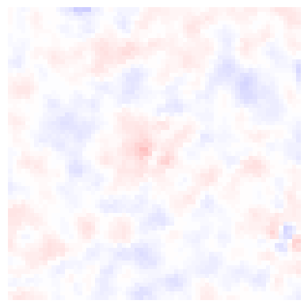

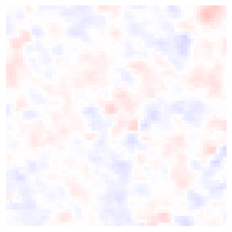

## Sample=1ejg-a:28:c-a:29:n-a:28:o

| pdb_code | central atom | ca density | parallel atom | pa density | planar atom | pl density |
| --- | --- | --- | --- | --- | --- | --- |
| 1ejg | [1.71, 14.08, 7.37] | 10.4015 | [1.62, 13.12, 6.45] | -4.9962 | [1.0, 14.08, 8.39] | 18.8887 |

## Slices along x,y and z

Sliced x-wise

Sliced y-wise

Sliced z-wise

33/67

33/67

33/67

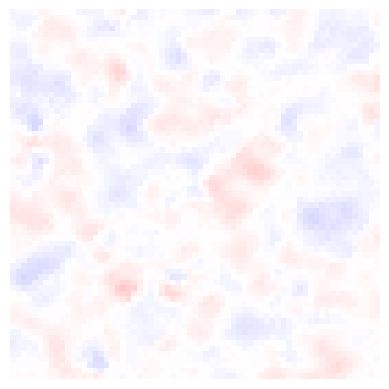

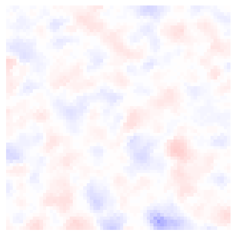

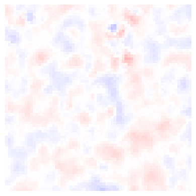

## Sample=1ejg-a:29:c-a:30:n-a:29:o

| pdb_code | central atom | ca density | parallel atom | pa density | planar atom | pl density |
| --- | --- | --- | --- | --- | --- | --- |
| 1ejg | [1.1, 11.1, 7.8] | 2.0028 | [2.41, 10.9, 7.98] | -1.7726 | [0.23, 10.55, 8.48] | -18.6693 |

## Slices along x,y and z

Sliced x-wise

Sliced y-wise

Sliced z-wise

33/67

33/67

33/67

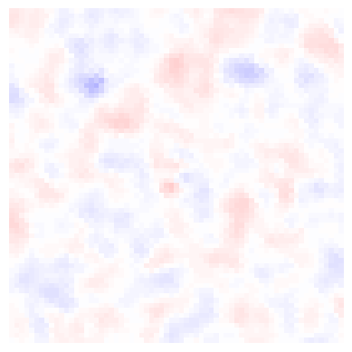

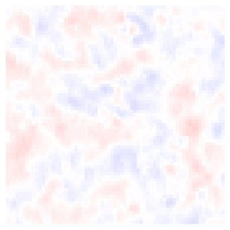

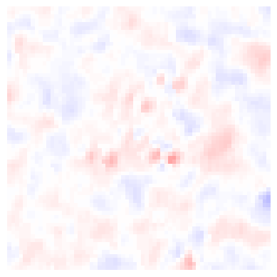

## Sample=1ejg-a:30:c-a:31:n-a:30:o

| pdb_code | central atom | ca density | parallel atom | pa density | planar atom | pl density |
| --- | --- | --- | --- | --- | --- | --- |
| 1ejg | [3.53, 10.42, 10.19] | -6.7358 | [3.93, 11.69, 10.2] | -2.9312 | [3.7, 9.61, 11.11] | -11.3883 |